# Question

A bucket filled with water will be pulled up 53 meters from the bottom of a well. The bucket is pulled up by a heavy rope that connects the pulley to the bucket. As the bucket is lifted, this rope’s length decreases from 53 meters to 0 meters. The bucket and water together have a weight of 16 Newtons. The rope has a [linear weight density](https://en.wikipedia.org/wiki/Linear_density) of 2 Newtons per meter.

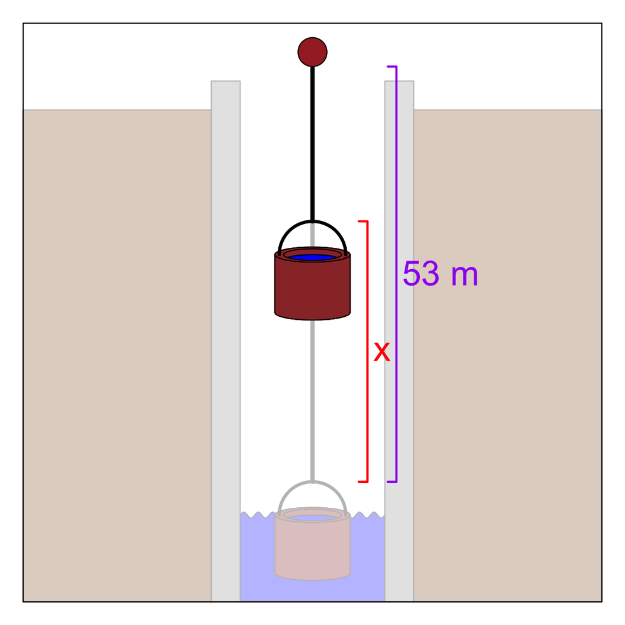

Each infinitesimal bit of work can be calculated from the product of force times infinitesimal displacement (change in height).

$$dW = F(x) \, dx$$

Notice that the force needed to lift the water, without acceleration, equals the total weight of the bucket, water, and rope between the pulley and the bucket. Because the length of rope decreases, the total weight decreases, so it gets easier to lift the bucket each millimeter.

The total work can be found by adding up all the infinitesimal bits of work. Find the total work in [Joules](https://en.wikipedia.org/wiki/Joule) (1 Joule equals 1 Newton$\cdot$meter). The tolerance is $\pm$ 100 [J](https://en.wikipedia.org/wiki/Joule).

# Solution

Figure out the force function. The weight of the bucket+water is always 16 Newtons. The rope weight starts at 106 Newtons, but decreases to 0 as the bucket is lifted. To find the weight of the rope, you multiply the linear weight density by the length of the rope.

$$F(x) = 16+2\cdot(53-x)$$

Write the integral with appropriate limits.

$$W ~=~ \int_{x=0}^{x=53} dW$$

Substitute.

$$W ~=~ \int_{0}^{53} F(x)\,dx$$
Substitute.

$$W ~=~ \int_{0}^{53}
\left(16+2\cdot(53-x)\right)\,dx$$

Simplify.

$$W ~=~ \int_{0}^{53}
\left(122-2x\right)\,dx$$

Use the antiderivative.

$$W ~=~
\left[122x-1x^2\right]_{0}^{53}$$

Use the limits.

$$W ~=~
\left(122\cdot(53)-1\cdot(53)^2\right)-\left(122\cdot(0)-1\cdot(0)^2\right)$$

Get rid of the zero terms.

$$W ~=~
122\cdot(53)-1\cdot(53)^2$$

Evaluate.

$$W ~=~ 3657$$

So the work equals approximately 3700 J, or about 0.87 [food calories](https://en.wikipedia.org/wiki/Calorie#Nutrition).

# Meta-information

extype: num exsolution: 3657 exname: bucket_work extol: 100